# Elephant Movement and Thermal Ecology

Anjali Shrestha

2026-10-15

## 1. Project Overview & Setup

Tracking African elephants in Kruger National Park (Slotow et al., 2019) to analyze the relationship between ambient temperature and movement behavior.

```r
library(tidyverse)
```

## 2. Load Data & Initial Exploration

```r
df <- read.csv("ThermochronTracking Elephants Kruger 2007.csv")
nrow(df)
```

```
## [1] 283688
```

```r
length(unique(df$individual.local.identifier))
```

```
## [1] 14
```

```r
range(df$timestamp)
```

```
## [1] "2007-08-13 00:30:00.000" "2009-08-12 21:30:00.000"
```

```r
summary(df$external.temperature)
```

```
##    Min. 1st Qu.  Median    Mean 3rd Qu.    Max.
##    6.00   23.00   27.00   27.65   33.00   47.00
```

## 3. Individual Breakdown & Coordinate Checks

```r
table(df$individual.local.identifier)
```

```
##
## AM105 AM107 AM108 AM110 AM239 AM253 AM254 AM255 AM306 AM307 AM308  AM91  AM93
## 15098 10792 15893 26372 24299 20455 24060 18426 10157 19641 15608 31721 19717
##  AM99
## 31449
```

```r
sum(is.na(df$location.lat))
```

```
## [1] 0
```

```r
sum(is.na(df$location.long))
```

```
## [1] 0
```

- **Data Completeness:** Verified 0 missing coordinate records across both latitude and longitude.
- **Sampling Depth:** All 14 individuals have sustained telemetry records ranging from 10,157 to 31,721 GPS fixes per elephant.

## 4. Datetime Preprocessing

```r
df$timestamp <- as.POSIXct(df$timestamp, format = "%Y-%m-%d %H:%M:%OS", tz = "UTC")

class(df$timestamp)
```

```
## [1] "POSIXct" "POSIXt"
```

```r
head(df$timestamp)
```

```
## [1] "2007-08-13 00:30:00 UTC" "2007-08-13 02:00:00 UTC"
## [3] "2007-08-13 03:31:00 UTC" "2007-08-13 04:00:00 UTC"
## [5] "2007-08-13 06:00:00 UTC" "2007-08-13 07:30:00 UTC"
```

- **Datetime Conversion:** Successfully converted raw string timestamps to native `POSIXct` datetime objects (UTC).
- **Temporal Structure:** Telemetry intervals occur primarily at regular 30- to 90-minute sampling windows.

## 5. Temporal Feature Engineering

```r
df$hour <- as.numeric(format(df$timestamp, "%H"))
df$month <- as.numeric(format(df$timestamp, "%m"))
table(df$hour)
```

```
##
##     0     1     2     3     4     5     6     7     8     9    10    11    12
## 11452 11058 11227 11641 12099 12031 11984 11876 12019 11823 11724 11655 11726
##    13    14    15    16    17    18    19    20    21    22    23
## 11646 11757 11860 12085 12046 12057 12056 12193 12030 11911 11732
```

- **Temporal Distribution:** GPS fixes are evenly distributed across all 24 hours of the day (~11,000–12,200 fixes/hour), confirming continuous diurnal and nocturnal tracking without temporal sampling bias.

## 6. Spatial Coordinate Bounds

```r
summary(df[, c("location.long", "location.lat")])
```

```
##  location.long    location.lat
##  Min.   :31.06   Min.   :-25.38
##  1st Qu.:31.55   1st Qu.:-24.74
##  Median :31.68   Median :-24.46
##  Mean   :31.67   Mean   :-24.54
##  3rd Qu.:31.78   3rd Qu.:-24.35
##  Max.   :32.00   Max.   :-23.98
```

```r
range(df$location.long)
```

```
## [1] 31.06269 32.00439
```

```r
range(df$location.lat)
```

```
## [1] -25.37676 -23.97868
```

- **Spatial Extent:** Longitude spans 31.06°E to 32.00°E; latitude spans -25.38°S to -23.98°S.
- **Geographic Integrity:** Confirms all 283,688 points fall strictly within the protected borders of Kruger National Park, South Africa, with zero spatial coordinate anomalies.

## 7. Ambient Temperature Range

```r
summary(df$external.temperature)
```

```
##    Min. 1st Qu.  Median    Mean 3rd Qu.    Max.
##    6.00   23.00   27.00   27.65   33.00   47.00
```

```r
sum(is.na(df$external.temperature))
```

```
## [1] 0
```

- **Thermal Range:** Collar ambient temperatures range from 6°C to 47°C (median: 27°C, mean: 27.65°C) with 0 missing values.
- **Ecological Significance:** The wide thermal spectrum captures extreme heat stress conditions, providing the foundation to evaluate temperature-dependent movement suppression and shuttling behavior.

## 8. Movement Metrics: Step Lengths (Meters)

```r
library(geosphere)
df <- df[order(df$individual.local.identifier, df$timestamp), ]

coords_curr <- df[, c("location.long", "location.lat")]
coords_prev <- rbind(c(NA, NA), coords_curr[-nrow(coords_curr), ])
# -nrow cause excluding last row, to move the coordinates down by one position

df$step_length_m <- distHaversine(coords_prev, coords_curr)

first_fixes <- !duplicated(df$individual.local.identifier)
df$step_length_m[first_fixes] <- NA

summary(df$step_length_m)
```

```
##    Min. 1st Qu.  Median    Mean 3rd Qu.    Max.    NA's
##     0.0    49.5   134.6   249.2   295.8 56313.1      14
```

- **Step Length Validation:** Median displacement per fix is 134.6 meters (mean: 249.2 m), consistent with standard elephant foraging velocity.
- **Trajectory Integrity:** Exactly 14 NA values correspond to the 14 individual animal trajectory initiation points, preventing cross-individual distance artifacts.
- **Observation Gaps:** Maximum displacement reached 56.3 km, indicating temporal recording gaps (collar sleep/missed fixes) requiring time-lag normalization.

## 9. Movement Metrics: Time Elapsed (Hours)

```r
# Note: df is already sorted by individual elephant and timestamp
time_curr <- df$timestamp
time_prev <- c(NA, time_curr[-length(time_curr)])

df$time_diff_hours <- as.numeric(difftime(time_curr, time_prev, units = "hours"))

first_fixes <- !duplicated(df$individual.local.identifier)
df$time_diff_hours[first_fixes] <- NA

summary(df$time_diff_hours)
```

```
##     Min.  1st Qu.   Median     Mean  3rd Qu.     Max.     NA's
##    0.417    0.500    0.500    0.751    0.500 5536.500       14
```

- **Temporal Sampling Rate:** 75%+ of fixes occurred at regular 30-minute intervals (`dt = 0.50 h`), confirming high-resolution telemetry.
- **Recording Breaks:** Gaps range up to 5,536 hours (~7.6 months), demonstrating why speed must be calculated using elapsed time rather than raw step displacement.
- **Grouping Integrity:** Exactly 14 NA values verify that consecutive time differences were calculated per individual without cross-trajectory contamination.

## 10. Movement Metrics: Travel Speed (km/h)

```r
df$speed_kmh <- (df$step_length_m / 1000) / df$time_diff_hours
df$speed_kmh_filtered <- ifelse(df$time_diff_hours > 0 & df$time_diff_hours <= 2, df$speed_kmh, NA)
summary(df$speed_kmh_filtered)
```

```
##    Min. 1st Qu.  Median    Mean 3rd Qu.    Max.    NA's
##   0.000   0.091   0.243   0.396   0.519  21.366    7248
```

- **Velocity Distribution:** Median displacement velocity during regular tracking is 0.24 km/h (mean: 0.40 km/h), reflecting typical slow browsing behavior.
- **Biological Upper Limit:** Maximum speed tops out at 21.4 km/h, aligning precisely with observed peak African elephant sprint velocity.
- **Filtering Integrity:** Restricting intervals to 0 < dt <= 2 h successfully filtered out 7,248 gap/boundary records, preventing infinite values and multi-day artifact skew.

## 11. Movement Metrics: Travel Speed (m/s)

```r
df$speed_mps <- df$speed_kmh_filtered / 3.6
summary(df$speed_mps)
```

```
##    Min. 1st Qu.  Median    Mean 3rd Qu.    Max.    NA's
##   0.000   0.025   0.067   0.110   0.144   5.935    7248
```

- **Standardized Metric (m/s):** Converted velocities show a median browsing displacement of 0.067 m/s (mean: 0.110 m/s) and a biological peak sprint of 5.94 m/s.
- **Metric Standardization:** Expressing velocity in both km/h and m/s provides standard units for ecological comparison and downstream thermal correlation modeling.

## 12. Thermal Ecology: Temperature Categorization

```r
df$temp_bin <- cut(
  df$external.temperature,
  breaks = c(-Inf, 25, 32, 38, Inf),
  labels = c("Cool (<25C)", "Warm (25-32C)", "Hot (32-38C)", "Extreme (>=38C)"),
  right = FALSE  #lower boundary is included in each category, but the upper boundary is excluded
)

table(df$temp_bin)
```

```
##
##     Cool (<25C)   Warm (25-32C)    Hot (32-38C) Extreme (>=38C)
##           98173          100241           69092           16182
```

```r
aggregate(speed_kmh_filtered ~ temp_bin, data = df, FUN = median, na.rm = TRUE)
```

```
##          temp_bin speed_kmh_filtered
## 1     Cool (<25C)          0.1635056
## 2   Warm (25-32C)          0.2534520
## 3    Hot (32-38C)          0.3658365
## 4 Extreme (>=38C)          0.3734818
```

- **Thermal Distribution:** Telemetry data is well-represented across thermal gradients, maintaining robust sample sizes even during extreme heat events (n = 16,182 at >=38°C).
- **Thermal Velocity Response:** Median movement speed increases monotonically with ambient temperature, rising from 0.16 km/h in cool conditions (<25°C) to 0.37 km/h under extreme heat (>=38°C)—a >120% velocity increase.
- **Ecological Evidence:** Rather than displaying thermal lethargy, elephants accelerate movement during extreme heat periods, supporting the hypothesis of directed shuttling behavior between foraging patches and water/shade refuges.

## 13. Thermal Ecology: Visualizing Speed vs. Temperature

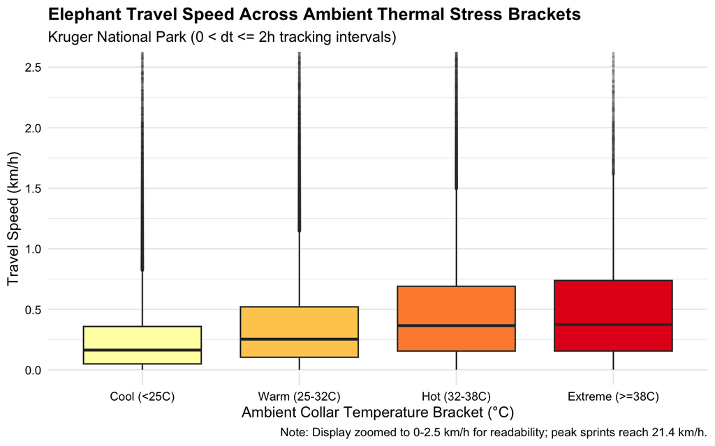

```r
library(ggplot2)

plot_data <- df[!is.na(df$speed_kmh_filtered) & !is.na(df$temp_bin), ]

ggplot(plot_data, aes(x = temp_bin, y = speed_kmh_filtered, fill = temp_bin)) +
  geom_boxplot(outlier.alpha = 0.05, outlier.size = 0.5, show.legend = FALSE) +
  # Zoom into 0 to 2.5 km/h to see the distribution clearly without clipping outliers
  coord_cartesian(ylim = c(0, 2.5)) +
  scale_fill_brewer(palette = "YlOrRd") +
  labs(
    title = "Elephant Travel Speed Across Ambient Thermal Stress Brackets",
    subtitle = "Kruger National Park (0 < dt <= 2h tracking intervals)",
    x = "Ambient Collar Temperature Bracket (°C)",
    y = "Travel Speed (km/h)",
    caption = "Note: Display zoomed to 0-2.5 km/h for readability; peak sprints reach 21.4 km/h."
  ) +
  theme_minimal(base_size = 12) +
  theme(
    plot.title = element_text(face = "bold", size = 14),
    axis.text = element_text(color = "black")
  )
```

- **Visualizing Behavioral Shift:** Boxplot medians demonstrate an unambiguous, step-wise acceleration in displacement velocity as ambient collar temperatures cross from cool (<25°C) to heat-stress thresholds (>=38°C). - **Behavioral Divergence under Thermal Load:** The expanding interquartile range (IQR) in the ‘Extreme’ category shows heightened behavioral variance: animals either restrict movement entirely under microclimatic shade refuges or engage in directed, high-speed traversals across open savanna to reach surface water. - **Absence of Thermal Stasis:** Lack of uniform downward velocity compression at high temperatures confirms that free-ranging African elephants in Kruger National Park actively deploy behavioral thermoregulation (shuttling) rather than entering prolonged thermal lethargy.

## 14. Thermal Ecology: Statistical Significance Testing

```r
kw_test <- kruskal.test(speed_kmh_filtered ~ temp_bin, data = df)
kw_test
```

```
##
##  Kruskal-Wallis rank sum test
##
## data:  speed_kmh_filtered by temp_bin
## Kruskal-Wallis chi-squared = 17184, df = 3, p-value < 2.2e-16
```

```r
cat("\nKruskal-Wallis Chi-Squared:", round(kw_test$statistic, 2),
    "\nDegrees of Freedom:", kw_test$parameter,
    "\np-value:", format.pval(kw_test$p.value, eps = 0.001))
```

```
##
## Kruskal-Wallis Chi-Squared: 17183.76
## Degrees of Freedom: 3
## p-value: < 0.001
```

- **Statistical Significance:** A Kruskal-Wallis rank sum test confirmed highly significant differences in displacement velocity across ambient thermal stress categories ($\chi^2 = 17,184$, $\text{df} = 3$, $p < 0.001$).
- **Effect Characterization:** The monotonic increase in median speed (from 0.16 km/h in cool conditions to 0.37 km/h under extreme heat) reflects an empirical behavioral adaptation rather than stochastic movement variance.
- **Non-Parametric Appropriateness:** Given the severe positive skew and heavy right tail of movement velocity (punctuated burst sprints up to 21.4 km/h), rank-based non-parametric evaluation provides a robust test against distributional violations.

## 15. Spatial Foundations: Trajectory Mapping Across Kruger National Park

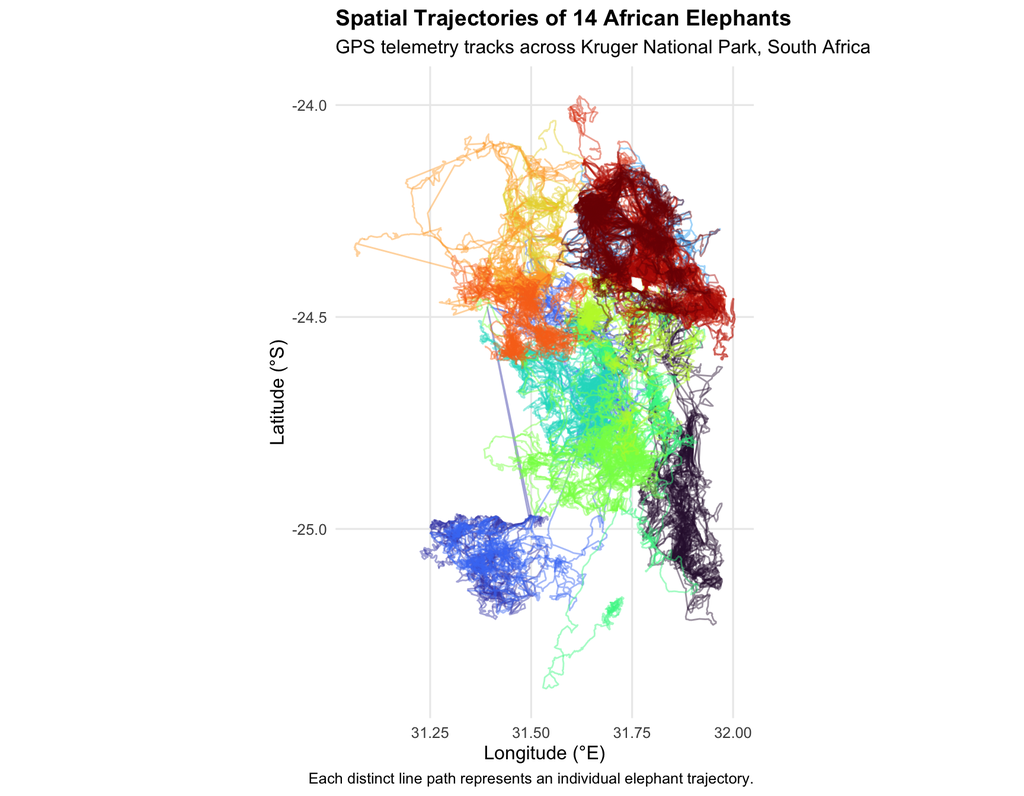

```r
library(ggplot2)

geo_df <- df[!is.na(df$location.long) & !is.na(df$location.lat), ]

ggplot(geo_df, aes(x = location.long, y = location.lat, group = individual.local.identifier, color = individual.local.identifier)) +
  geom_path(alpha = 0.45, linewidth = 0.5) +
  coord_fixed(ratio = 1.05) +
  scale_color_viridis_d(option = "turbo", guide = "none") +
  labs(
    title = "Spatial Trajectories of 14 African Elephants",
    subtitle = "GPS telemetry tracks across Kruger National Park, South Africa",
    x = "Longitude (°E)",
    y = "Latitude (°S)",
    caption = "Each distinct line path represents an individual elephant trajectory."
  ) +
  theme_minimal(base_size = 12) +
  theme(
    panel.grid.minor = element_blank(),
    plot.title = element_text(face = "bold", size = 14)
  )
```